# Prostate_GDSC_profiles_PKN

AM

Done May 2018 - Run 2018-06-04

## Objectives

Generate patients profiles from GDSC data for further logical modelling.

# Independent omics profiles

## CellLines dataset recap

Most patients have all omics data:

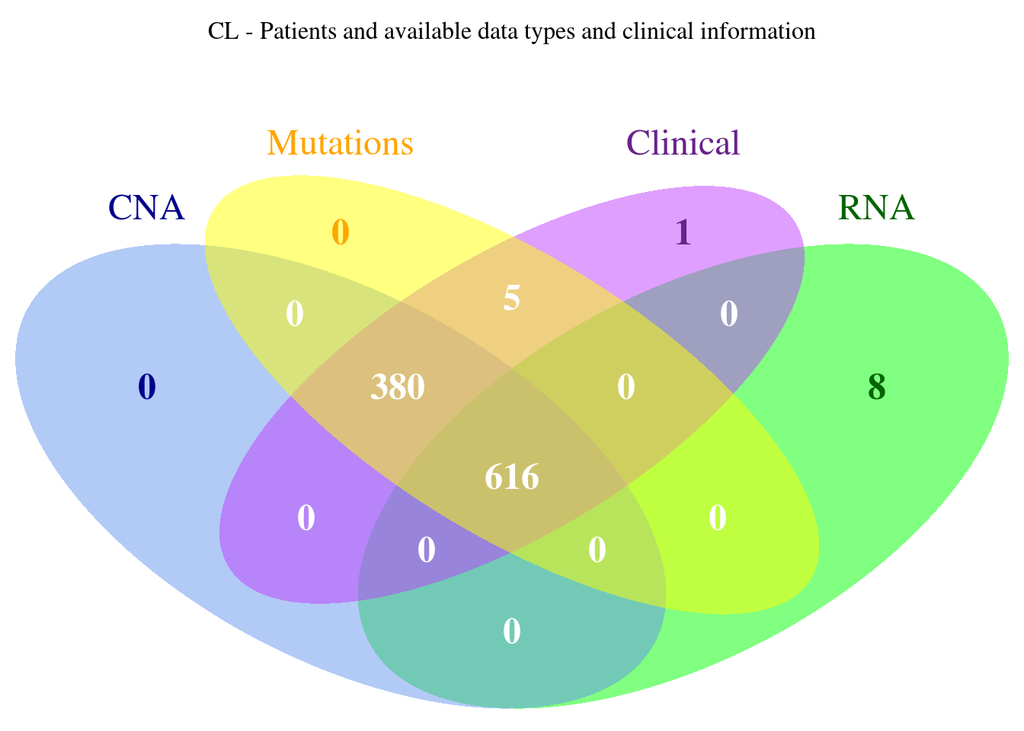

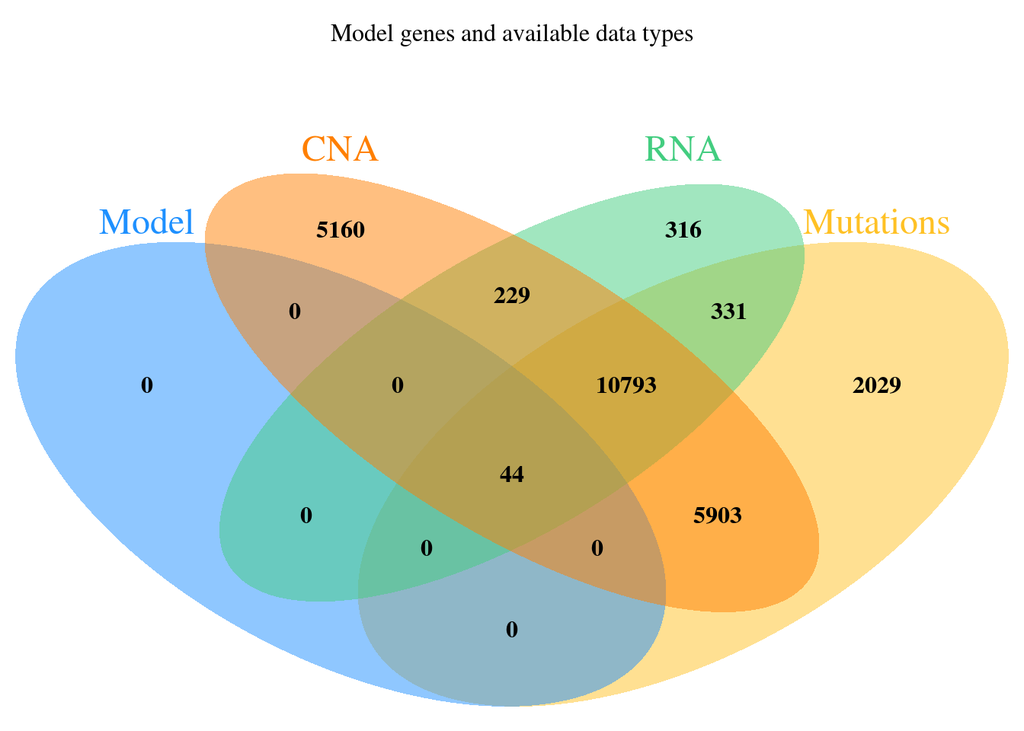

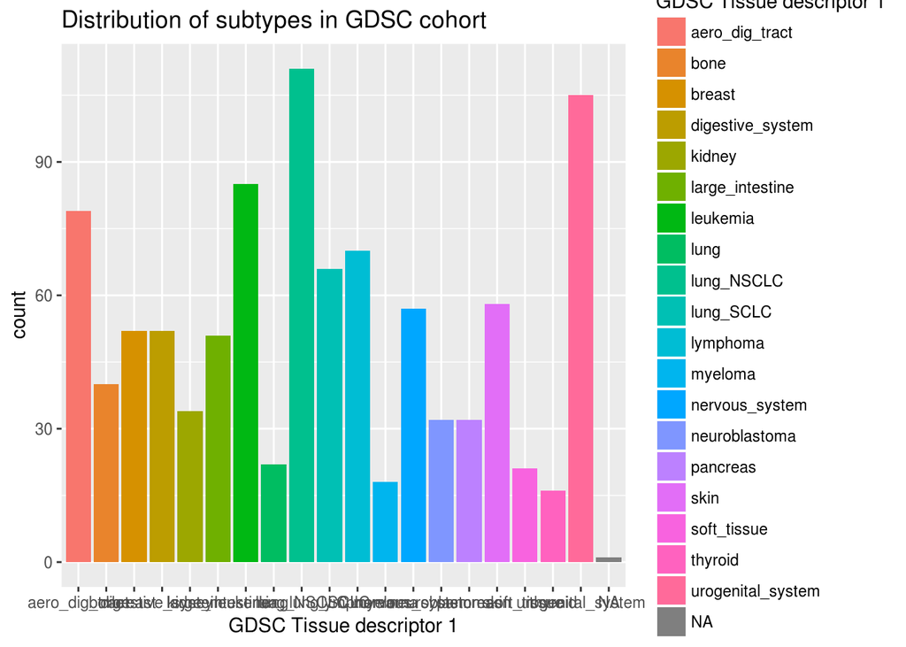

RNAseq for all genes is projected on PC1/PC2 space (from Principal Component Analysis).

[figure not shown]

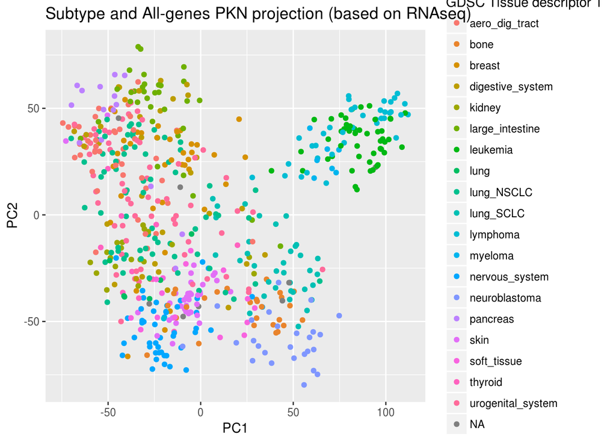

# Processing pipeline

## Mutations profiles

We need to assign Boolean effects to mutations: either 0 (inactivating) or 1 activating. A mutation can stay unassigned in absence of any evidence.

Assignement methods and their respective influence:

```
## [1] "Sankey plots of mutation assignments depending on methods used"
```

[interactive chart not shown]

```
## [1] "Sankey plots of mutation assignments depending on methods used (restricted to model-related nodes)"
```

[interactive chart not shown]

Now we can summarize patient mutation profiles after processing. In following plots we focus on model-related genes only.

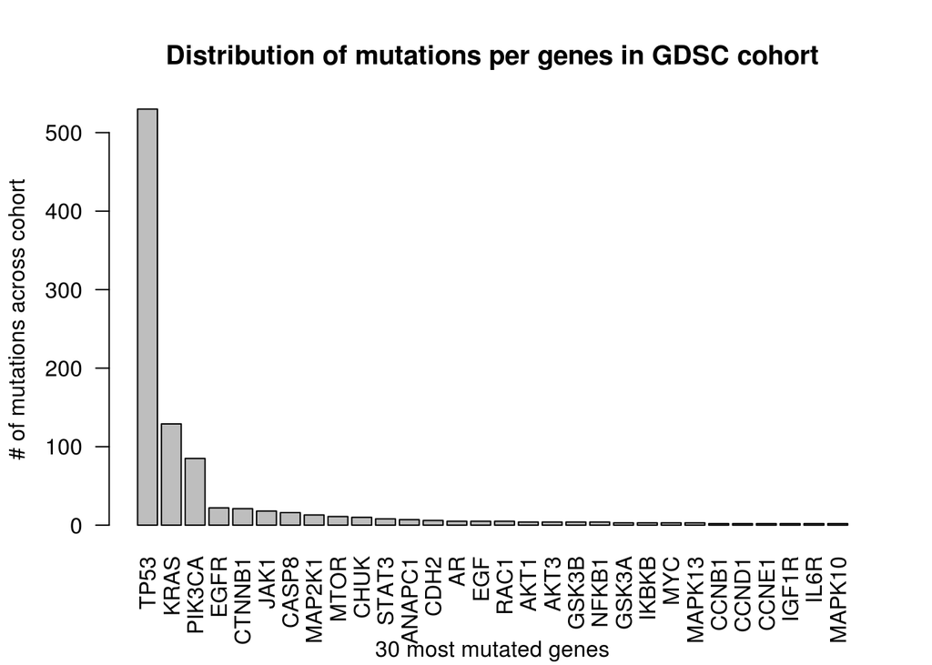

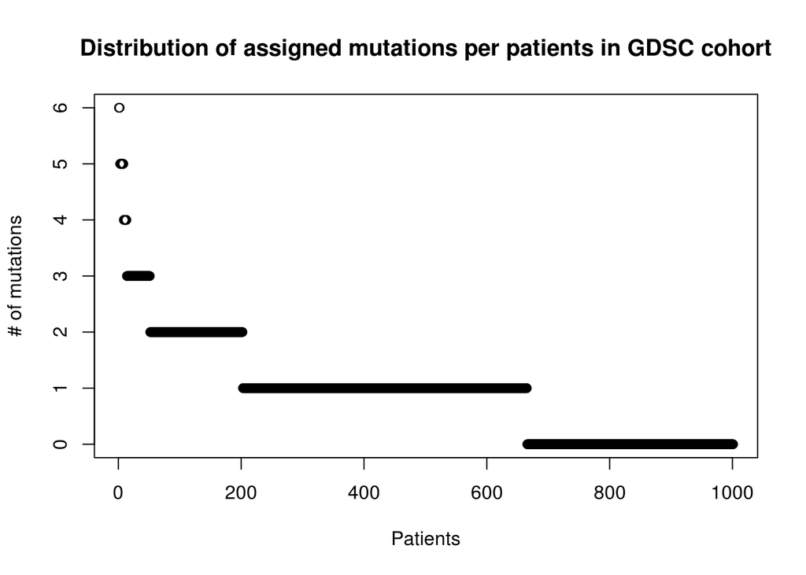

## CNA profiles

For CNA, we have decided to focus on stringent amplifications/deletions corresponding to +2/-2 GISTIC results. We produce the same kind of plots.

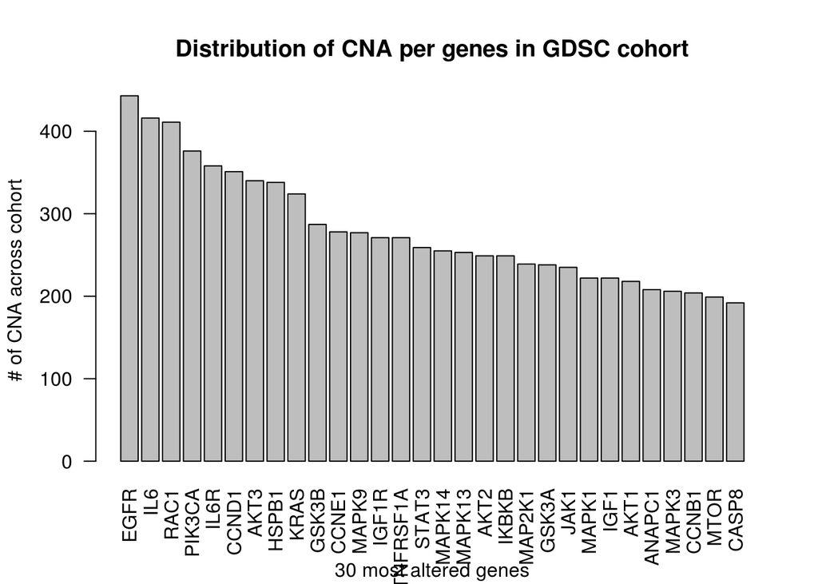

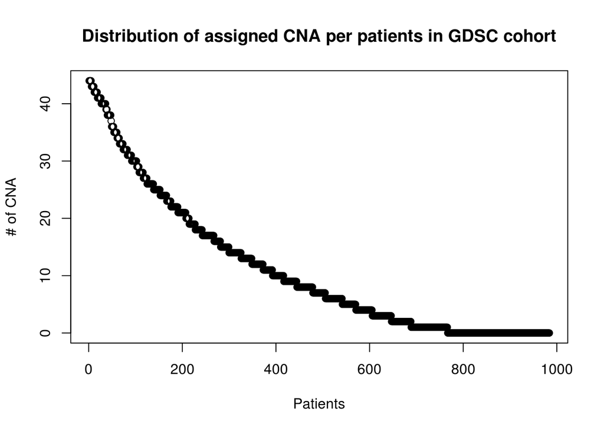

## RNA profiles

RNA data is intrinsically continuous and therefore require preliminary data processing. It is important to notice that GDSC data is RNAseq (contrary to METABRIC data coming from microarray).

### Binarization with classification tree

Now, what about the distribution of gene categories (Bimodal, Unimodal…) across the cohort?

```
## [1] "GDSC assignments:"
```

| Bimodal | Unimodal | ZeroInf |
| --- | --- | --- |
| 310 | 10046 | 1357 |

```
## [1] "CL_ref assignments:"
```

| Unimodal |
| --- |
| 11713 |

```
## [1] "Consistency between both sub-cohorts:"
```

|  | Unimodal |
| --- | --- |
| Bimodal | 310 |
| Unimodal | 10046 |
| ZeroInf | 1357 |

```
## [1] "GDSC assignments for model-related nodes:"
```

| Unimodal |
| --- |
| 44 |

Here are some distributions plots randomly picked in each category in GDSC cohort

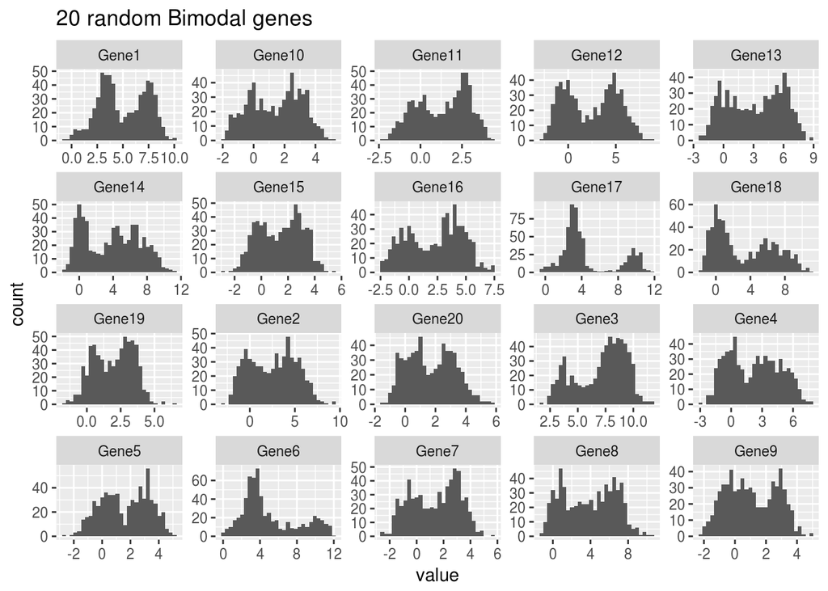

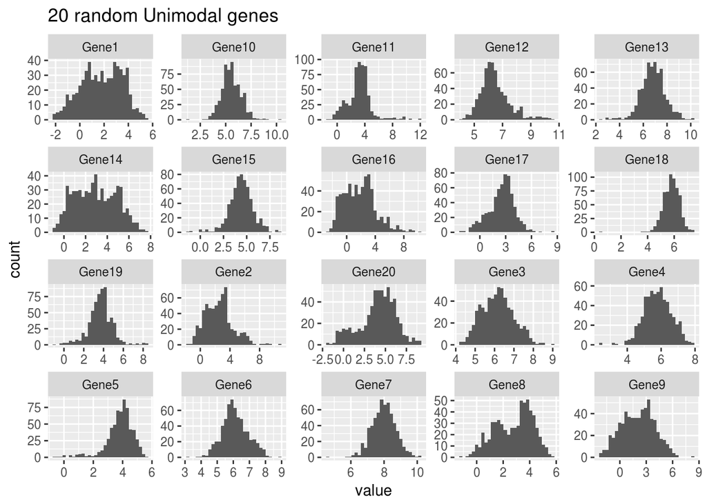

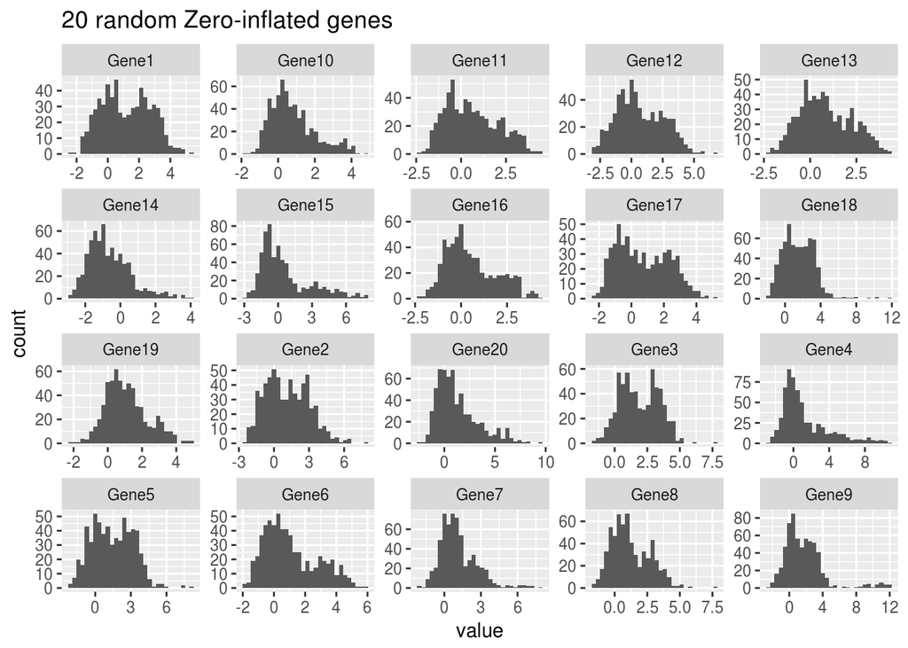

And depending on distribution category, we can perform binarization

```
## [1] "Bimodal example:"
```

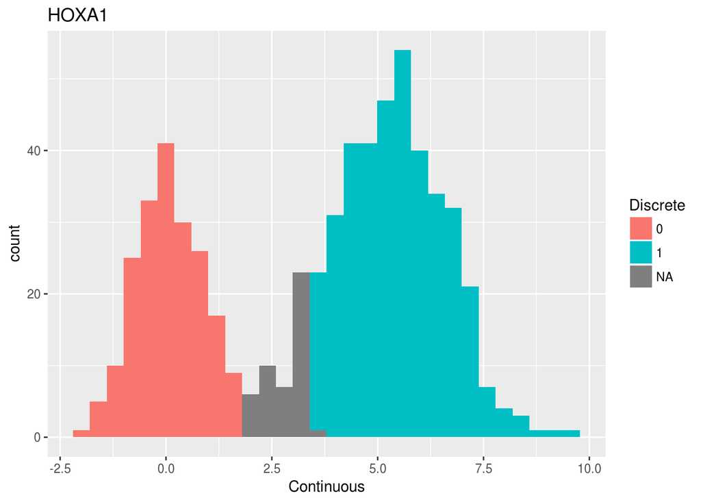

```
## [1] "Unimodal example:"
```

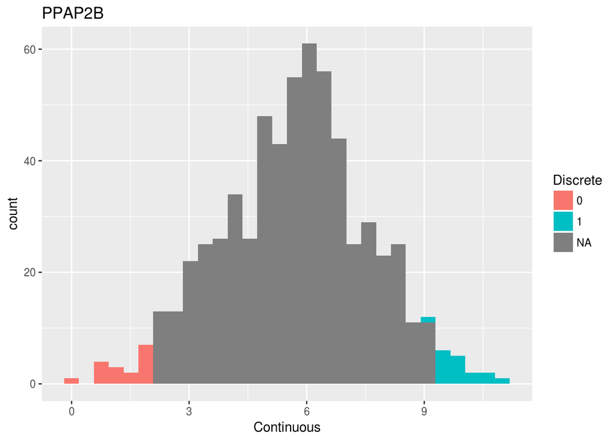

```
## [1] "ZeroInf example:"
```

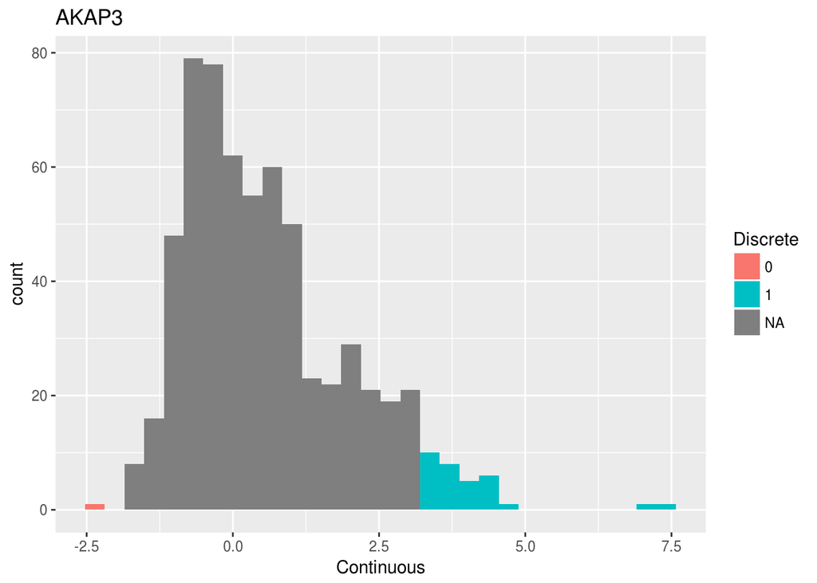

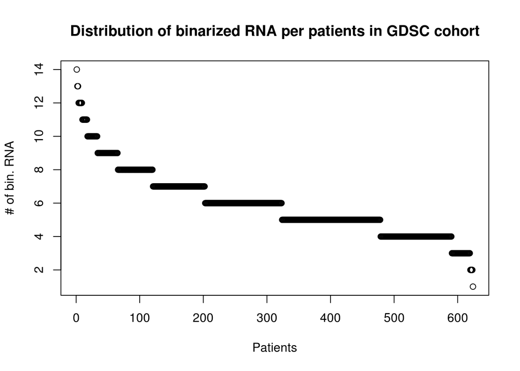

[figure not shown]

```
## [1] "Some possible differences between methods w/ and w/o reference"
```

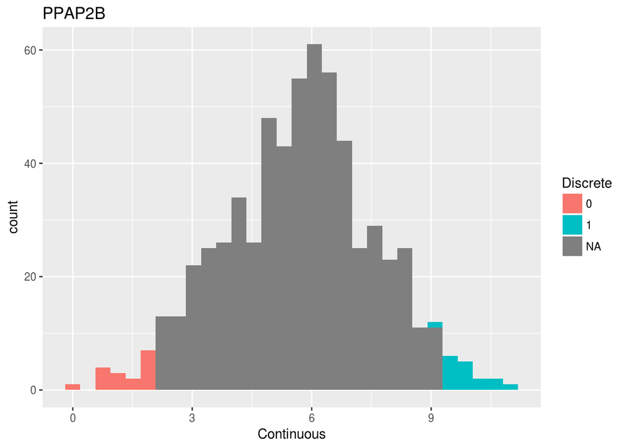

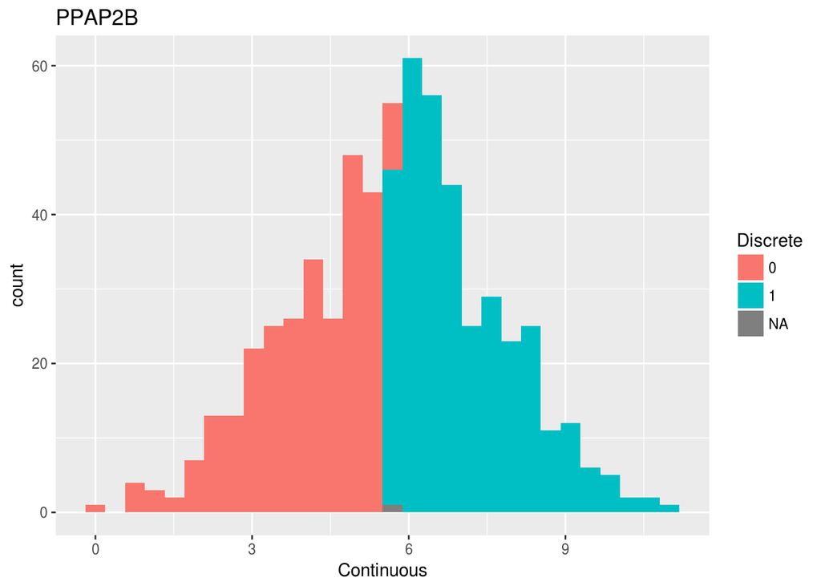

# Merged profiles

## Data types relations

Before merging independent profiles into multi-omics profiles, let’s have a look at relations between data types

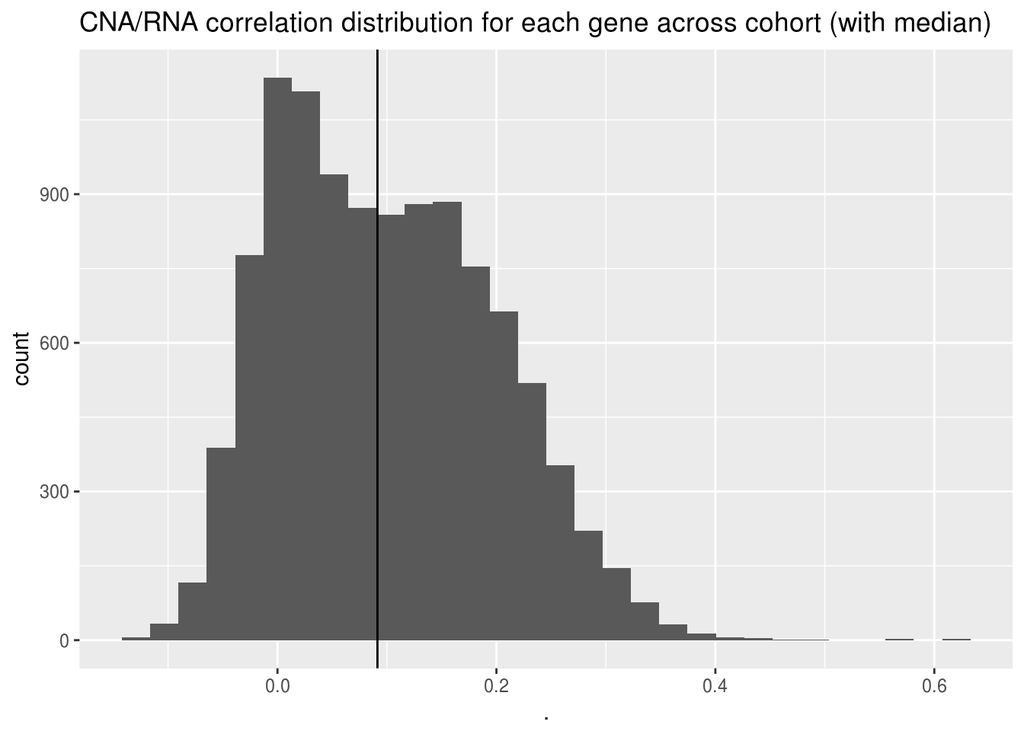

### Mutations and CNA

In particular, is there any mutation/CNA binary inconsistency?

| Patient | Gene | Mut | CNA |
| --- | --- | --- | --- |
| SNU-1040 | AKT1 | 0 | 1 |
| K-562 | AKT3 | 0 | 1 |
| MZ7-mel | AKT3 | 0 | 1 |
| U-2-OS | CTNNB1 | 0 | 1 |
| IGROV-1 | CASP8 | 0 | 1 |
| EN | ANAPC1 | 0 | 1 |
| EN | CCNB1 | 0 | 1 |
| DND-41 | EGFR | 0 | 1 |
| MOLT-4 | EGFR | 0 | 1 |
| CCK-81 | GSK3A | 0 | 1 |
| CCK-81 | CHUK | 0 | 1 |
| IGROV-1 | CHUK | 0 | 1 |
| SNU-1040 | CHUK | 0 | 1 |
| EN | JAK1 | 0 | 1 |
| HEC-1 | JAK1 | 0 | 1 |
| IGROV-1 | JAK1 | 0 | 1 |
| LNCaP-Clone-FGC | JAK1 | 0 | 1 |
| MOLT-4 | JAK1 | 0 | 1 |
| HCC2218 | NFKB1 | 0 | 1 |
| HCC1937 | MAPK13 | 0 | 1 |
| SF539 | MAPK13 | 0 | 1 |
| 451Lu | TP53 | 0 | 1 |
| 786-0 | TP53 | 0 | 1 |
| BFTC-909 | TP53 | 0 | 1 |
| BT-549 | TP53 | 0 | 1 |
| CA46 | TP53 | 0 | 1 |
| Calu-6 | TP53 | 0 | 1 |
| CAS-1 | TP53 | 0 | 1 |
| COLO-680N | TP53 | 0 | 1 |
| COR-L279 | TP53 | 0 | 1 |

[output cut: 80 more lines]

In case of ambiguity, pritority is given to mutations over CNA

### CNA and RNA

| Patient | Gene | CNA | RNA |
| --- | --- | --- | --- |
| EB2 | AKT1 | 1 | 0 |
| JVM-3 | AKT1 | 1 | 0 |
| A498 | AKT2 | 1 | 0 |
| A431 | AKT3 | 1 | 0 |
| ATN-1 | AKT3 | 1 | 0 |
| C2BBe1 | AKT3 | 1 | 0 |
| CA46 | AKT3 | 1 | 0 |
| CAL-148 | AKT3 | 1 | 0 |
| Caov-3 | AKT3 | 1 | 0 |
| COLO-205 | AKT3 | 1 | 0 |
| COLO-680N | AKT3 | 1 | 0 |
| Daudi | AKT3 | 1 | 0 |
| DSH1 | AKT3 | 1 | 0 |
| EB2 | AKT3 | 1 | 0 |
| EFM-19 | AKT3 | 1 | 0 |
| EFO-21 | AKT3 | 1 | 0 |
| HC-1 | AKT3 | 1 | 0 |
| HCC1187 | AKT3 | 1 | 0 |
| HCC1419 | AKT3 | 1 | 0 |
| HCC1954 | AKT3 | 1 | 0 |
| HCC2218 | AKT3 | 1 | 0 |
| HCC70 | AKT3 | 1 | 0 |
| HEC-1 | AKT3 | 1 | 0 |
| HGC-27 | AKT3 | 1 | 0 |
| HT55 | AKT3 | 1 | 0 |
| IGROV-1 | AKT3 | 1 | 0 |
| JVM-3 | AKT3 | 1 | 0 |
| KMOE-2 | AKT3 | 1 | 0 |
| KURAMOCHI | AKT3 | 1 | 0 |
| KY821 | AKT3 | 1 | 0 |

[output cut: 358 more lines]

In case of ambiguity, pritority is given to RNA over CNA

### RNA and Prot - Not applicable

When available, prot is used. Otherwise, we use RNA

### Mut and Exp - Not applicable